# 2. Data Processing for the Mobile Air Monitoring Project

Xiaoman Zhang

2024-02-28

```r
knitr::opts_chunk$set(message = FALSE, error = FALSE)
# Libraries needed

library(lubridate)
library(ggpubr)
library(dplyr)
library(tidyr)
```

# 2. Data processing

## 2.1 Import and prepare GPS and DX4040 data

```r
# 1. import dx4040 data
## dx4040 took measurement every 7-9s (the variation is due to the 2-4s analysis time)
dx<-read.csv("240221_dx_ori.csv")

# Remove unneeded cols
head(dx)
```

```
##   Line      Date     Time                                   SpectrumFile
## 1    0 2024/2/21 09:37:33 C:\\CalcmetSamples\\20240221\\SAMPLE_01339.SPE
## 2    0 2024/2/21 09:37:41 C:\\CalcmetSamples\\20240221\\SAMPLE_01340.SPE
## 3    0 2024/2/21 09:37:49 C:\\CalcmetSamples\\20240221\\SAMPLE_01341.SPE
## 4    0 2024/2/21 09:37:57 C:\\CalcmetSamples\\20240221\\SAMPLE_01342.SPE
## 5    0 2024/2/21 09:38:04 C:\\CalcmetSamples\\20240221\\SAMPLE_01343.SPE
## 6    0 2024/2/21 09:38:12 C:\\CalcmetSamples\\20240221\\SAMPLE_01344.SPE
##       LibraryFile Carbon.monoxide Unit Compensation Residual Nitrogen.monoxide
## 1 Asphalt_new.LIB               0  ppm          wet   0.0014              0.00
## 2 Asphalt_new.LIB               0  ppm          wet   0.0031              0.00
## 3 Asphalt_new.LIB               0  ppm          wet   0.0028              4.45
## 4 Asphalt_new.LIB               0  ppm          wet   0.0036              0.00
## 5 Asphalt_new.LIB               0  ppm          wet   0.0040              0.00
## 6 Asphalt_new.LIB               0  ppm          wet   0.0038              0.00
##   Unit.1 Compensation.1 Residual.1 Sulfur.dioxide Unit.2 Compensation.2
```

[output cut: 167 more lines]

```r
dx <- dx %>% select(- starts_with("Unit"), - starts_with("Compensation"),-starts_with("Residual"),-Line,-Date,-SpectrumFile,-LibraryFile,-Cell.temperature,-Status)

# prepare dx4040 data: convert Time from character to POSIXct objects
date <- "2024-02-21"
dx$Time <- ymd_hms(paste(date, dx$Time),tz="America/Chicago")
# other option:
# dx$Time <- as.POSIXct(paste(date, dx$Time), format="%Y-%m-%d %H:%M:%S", tz="America/Chicago")
dx$Time <- round_date(dx$Time, unit = "second")

rm(date)
# head(dx)
# sapply(dx,class)
# summary(dx)

#2. import gps data
## Most gps data has an interval about 1s.
## The gps will not record the time point when the distance traveled during an interval is less than 1m
gps_1<-read.csv("240221_gps_1.csv")
gps_2<-read.csv("240221_gps_2.csv")
gps <- rbind(gps_1,gps_2)
head(gps)
```

```
##                Date.GMT.            Date.Local.            Time.sec. Latitude
## 1 2024-02-21 15:36:14.02 2024-02-21 09:36:14.02 0.000706911087036133 41.86928
## 2 2024-02-21 15:36:15.02 2024-02-21 09:36:15.02 0.000706911087036133 41.86926
## 3 2024-02-21 15:36:16.03 2024-02-21 09:36:16.03     1.00559198856354 41.86925
## 4 2024-02-21 15:36:21.00 2024-02-21 09:36:21.00     6.00559198856354 41.86926
## 5 2024-02-21 15:37:27.00 2024-02-21 09:37:27.00     72.0064699649811 41.86921
## 6 2024-02-21 15:41:11.00 2024-02-21 09:41:11.00     296.054198026657 41.86923
##   Longitude Horizontal.Accuracy.m. Altitude.m. Vertical.Accuracy.m. Distance.m.
## 1 -87.66757               17.75665    183.6895             4.000000    0.000000
## 2 -87.66758               16.71426    183.4888             4.000000    0.000000
## 3 -87.66759               16.08392    183.1517             4.000000    1.491385
## 4 -87.66760               15.14912    184.2831             4.000000    2.817434
## 5 -87.66758               14.31792    182.1021             9.970856    8.492118
## 6 -87.66759               14.25217    181.9260            10.064617   11.250102
##   Speed.m.s. Average.Speed.m.s. Course.deg. True.Heading.deg.
## 1 0.75000000         11.2796118    99.14062          62.62170
## 2 0.00000000         11.2796118    99.14062          62.62170
## 3 0.00000000         11.2796118    99.14062          63.62696
## 4 0.00000000          0.1363688    99.14062          75.76658
## 5 0.00000000          0.0000000    -1.00000          75.76658
## 6 0.01805857          0.0000000    -1.00000          54.23190
##   Magnetic.Heading.deg. Heading.Accuracy.deg. Glide.Ratio Heart.Rate..bpm.
## 1              66.62170              29.14800   0.9672345                0
## 2              66.62170              29.14800   1.0337568                0
## 3              67.62696              29.15285   1.1032688                0
## 4              79.76658              29.17094   1.1095535                0
## 5              79.76658              29.17094   0.0000000                0
## 6              58.23190              29.16509   0.0000000                0
```

```r
# Prepare gps data
gps<- gps %>% select(Date.Local., Latitude, Longitude)
names(gps)[1]<-"Time"
gps$Time <- ymd_hms(as.character(gps$Time),tz="America/Chicago")
gps$Time <- round_date(gps$Time, unit = "second")

# Check for duplicates: There might be duplicates after round_date()
duplicates1 <- duplicated(gps$Time) | duplicated(gps$Time, fromLast = TRUE)
table(duplicates1)
```

```
## duplicates1
## FALSE  TRUE
## 14245     2
```

```r
table(gps$Time[duplicates1]) #2024-02-21 17:28:32
```

```
##
## 2024-02-21 17:28:32
##                   2
```

```r
# remove the duplicated time point by taking the average of the lat and lon
gps_dedu <- gps %>%
  group_by(Time) %>%
  summarise(across(.cols = where(is.numeric), ~mean(.x, na.rm = TRUE)))

# double check
# duplicates2 <- duplicated(gps_dedu$Time) | duplicated(gps_dedu$Time, fromLast = TRUE)
# table(duplicates2)
# table(gps_dedu$Time[duplicates2])
#
# gps[gps$Time=="2024-02-21 17:28:32",]
# gps_dedu[gps_dedu$Time=="2024-02-21 1:28:32",]

# Change the format
gps <- gps_dedu %>%
  mutate(Latitude = sprintf("%.6f", Latitude),
         Longitude = sprintf("%.6f", Longitude))

rm(duplicates1)
rm(gps_1,gps_2,gps_dedu)
```

## 2.2 Link gps data with dx4040 data by time

DX4040 and the gps device we used take measurement at different frequency. Most gps data points has an interval about 1s. However, when the distance traveled during an interval is less than 1m, the gps will not record the second time point. DX4040 data have a wider time interval than GPS, which is 7-9s. There is a 2s variation due the variation in the device’s analysis time. To link the two dataframes, I first created gps_filled, where the gps data is in 1s interval. I filled the empty longitude and latitude cells by copying each one’s nearest upper cell, as the GPS stops recording when the distance traveled during a time interval is less than 1m. Then, I calculated the latitude and longitude of each dx data point by taking the average of their corresponding latitudes and longitudes (those in the same time interval) in gps_filled. Before taking the average, I checked the boundries (the start, the end, and the gap ) to make sure they are in the right structure for the following code. There is a gap in both dataframes as we stopped taking measurements during the lunch break.

```r
# 1. Create gps_filled: 1s interval gps data
gps$Time %>% summary
```

```
##                       Min.                    1st Qu.
## "2024-02-21 09:36:14.0000" "2024-02-21 11:33:43.2500"
##                     Median                       Mean
## "2024-02-21 14:32:09.5000" "2024-02-21 13:52:18.4846"
##                    3rd Qu.                       Max.
## "2024-02-21 15:59:49.7500" "2024-02-21 17:28:32.0000"
```

```r
dx$Time %>% summary
```

```
##                       Min.                    1st Qu.
## "2024-02-21 09:37:33.0000" "2024-02-21 11:20:30.5000"
##                     Median                       Mean
## "2024-02-21 14:01:38.0000" "2024-02-21 13:36:19.9026"
##                    3rd Qu.                       Max.
## "2024-02-21 15:44:39.0000" "2024-02-21 17:27:32.0000"
```

```r
time_seq <- seq(from = min(gps$Time), to = max(gps$Time), by = "sec")
new_df <- data.frame(Time = time_seq)

gps_filled <- new_df %>%
  left_join(gps, by="Time") %>%
  fill(everything()) # fill() fills values downwards by default

# Double-check
# tail(gps)
# ## check filling part
# gps_filled[gps_filled$Time=="2024-02-21 17:26:58",]
# gps_filled[gps_filled$Time=="2024-02-21 17:27:16",]
# gps_filled[28244:28263,]

rm(time_seq,new_df)

# 2. create df dx_gps
dx_gps <- dx
# add 2 empty col
dx_gps["latitude"] <- NA
dx_gps["longitude"] <- NA
# rearrange the col
dx_gps <- dx_gps[c(1, (ncol(dx_gps) - 1), ncol(dx_gps), 2:(ncol(dx_gps) - 2))]
dx_gps[1,c(1:5,ncol(dx_gps)-1,ncol(dx_gps))]
```

```
##                  Time latitude longitude Carbon.monoxide Nitrogen.monoxide
## 1 2024-02-21 09:37:33       NA        NA               0                 0
##   Carbon.Tetrachloride trans.1.3.Dichloropropene
## 1                    0                         0
```

```r
# 3. check the boundary
## 3.1 the Start: gps start early, no need to change things

# ## if dx starts earlier, delete the part with no gps data
# gps_filled[1,1] #"2024-01-31 10:56:36 CST"
# min(which(dx_gps$Time>="2024-01-31 10:56:36 CST"))
# dx_gps[102,1] # "2024-01-31 10:56:38 CST"
# dx_gps_d <- dx_gps[-(1:102),]
# ## check
# dx_gps_d[1:5,1:5]
# dx_gps[102:107,1:5]
# dx_gps <- dx_gps_d
# rm(dx_gps_d)

## 3.2 the End gps ends later, no need to change things
# ## the end: delet the dx data ends after the ending of gps
# dx_gps[nrow(dx_gps),1]
# gps_filled[nrow(gps_filled),1]
# which(dx_gps$Time>="2024-01-31 14:17:52 CST")
# dx_gps[911:913,1]
# dx_gps<-dx_gps[-(914:922),]

## 3.3 the gap
# the gap in gps data
which(gps_filled$Time=="2024-02-21 12:39:23") #10990
```

```
## [1] 10990
```

```r
which(gps_filled$Time=="2024-02-21 13:32:54") #14201
```

```
## [1] 14201
```

```r
which(gps$Time=="2024-02-21 12:39:23") #5941
```

```
## [1] 5941
```

```r
gps$Time[5941:5942]
```

```
## [1] "2024-02-21 12:39:23 CST" "2024-02-21 13:32:54 CST"
```

```r
# the gap in dx is between 1407 and 1408
which(dx_gps$Time>"2024-02-21 13:32:54")[1]
```

```
## [1] 1408
```

```r
dx_gps$Time[1407:1408]
```

```
## [1] "2024-02-21 12:37:40 CST" "2024-02-21 13:35:17 CST"
```

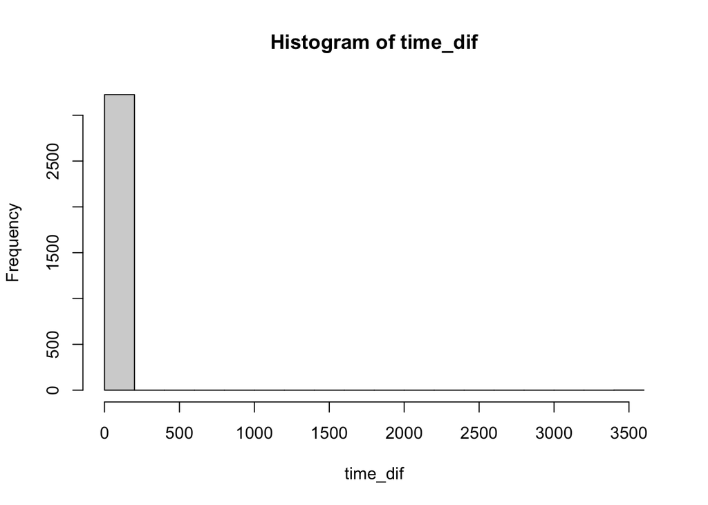

```r
# "2024-02-21 12:37:40 CST" # 1407
# "2024-02-21 13:35:17 CST" # 1408

## 3.4 find the average time interval between datapoints in dx
time_dif <- diff(dx_gps$Time)
time_dif <- as.numeric(time_dif)
hist(time_dif)
```

```r
time_dif[1407]
```

```
## [1] 3457
```

```r
time_dif <- time_dif[-1407]
summary(time_dif) # mean = 7.67, median=8
```

```
##    Min. 1st Qu.  Median    Mean 3rd Qu.    Max.
##   7.000   7.000   8.000   7.672   8.000   9.000
```

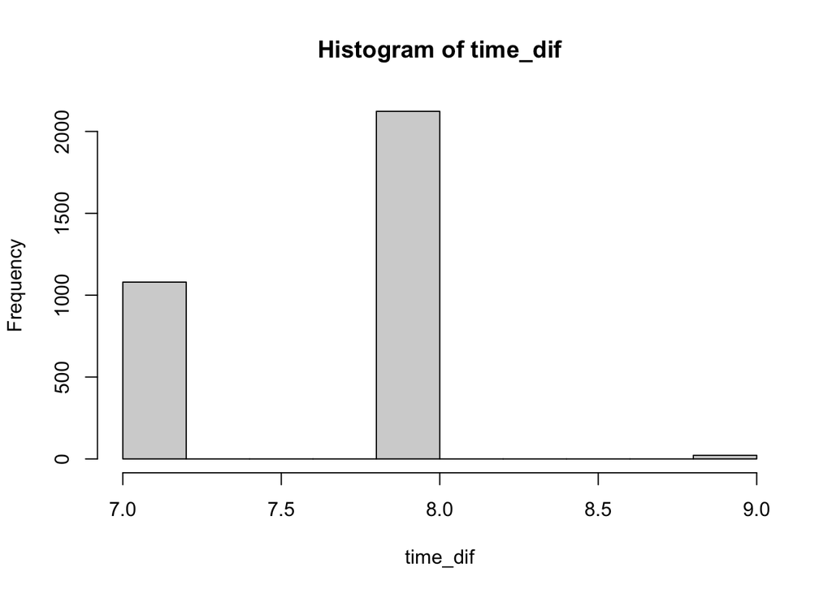

```r
hist(time_dif)
```

```r
# which(dx_gps$Time<="2024-01-31 13:04:03 CST" & dx_gps$Time>="2024-01-31 13:01:38 CST",)
# which(gps_filled$Time=="2024-01-31 13:04:03 CST")
# dx_gps[358:360,1]
# dx_gps_d <- dx_gps[-(340:360),]
# dx_gps[339:361,1]
# dx_gps_d[339:340,1]
# dx_gps <- dx_gps_d
# rm(dx_gps_d)

# 4. calculate the average latitudes and longitudes
gps_filled$Latitude <- as.numeric(gps_filled$Latitude)
gps_filled$Longitude <- as.numeric(gps_filled$Longitude)

for (i in 2:nrow(dx_gps)){
  if (i != 1408) { # 1480 is the end of the gap
    # print(i)
    dis = dx_gps[i,1]-dx_gps[i-1,1]
    in_end = which(gps_filled$Time==dx_gps[i,1])
    in_start = in_end - dis + 1
    dx_gps[i,2] = mean(gps_filled$Latitude[in_start:in_end])
    dx_gps[i,3] = mean(gps_filled$Longitude[in_start:in_end])
  }
  else {
    dis = 8 # average time interval between data points in dx
    in_end = which(gps_filled$Time==dx_gps[i,1])
    in_start = in_end - dis + 1
    dx_gps[i,2] = mean(gps_filled$Latitude[in_start:in_end])
    dx_gps[i,3] = mean(gps_filled$Longitude[in_start:in_end])
  }
}

# Double check
# dx_gps[2946:2947,1:3]
# gps_filled[gps_filled$Time=="2024-02-21 16:51:51",1:3]
# gps_filled[26131:26138,1:3] %>% summarise(mean(Latitude),mean(Longitude))
# dx_gps[2947,2:3]
head(dx_gps)
```

```
##                  Time latitude longitude Carbon.monoxide Nitrogen.monoxide
## 1 2024-02-21 09:37:33       NA        NA               0              0.00
## 2 2024-02-21 09:37:41 41.86921 -87.66758               0              0.00
## 3 2024-02-21 09:37:49 41.86921 -87.66758               0              4.45
## 4 2024-02-21 09:37:57 41.86921 -87.66758               0              0.00
## 5 2024-02-21 09:38:04 41.86921 -87.66758               0              0.00
## 6 2024-02-21 09:38:12 41.86921 -87.66758               0              0.00
##   Sulfur.dioxide Methane Carbon.dioxide Water.vapor O.Xylene P.Xylene Toluene
## 1              0    0.26          65.41        0.08     0.29     0.00       0
## 2              0    1.24         272.69        0.29     0.00     0.00       0
## 3              0    1.59         367.70        0.37     0.08     0.00       0
## 4              0    1.73         408.14        0.42     0.06     0.00       0
## 5              0    1.97         438.22        0.46     0.23     0.00       0
## 6              0    2.06         444.59        0.48     0.00     0.39       0
##   Benzene M.Xylene Styrene X1.2.Dichloroethane X1.3.butadiene
```

[output cut: 41 more lines]